# luad-survival

*Last modified `04:43 PM on May 21, 2016`. This document, R session image, knitr cache, figures, and other associated datasets are located in `cruncher:/inside/grotto/blin/trna-markers/luad/luad-survival/`.*

```r
library(survival)
library(glmnet)
library(GenomicRanges)
library("RColorBrewer")
library(pheatmap)
library(Hmisc)
library(reshape2)
library(qvalue)
source('/inside/home/blin/lib/R/ggsurv.R')
source('/inside/grotto/blin/trna-markers/luad/predict/predict.R')
load('/inside/home/blin/grotto/data/hg19-srnas.RData')
load('/inside/home/blin/grotto/trna-markers/process-reads/luad-counts.RData')
load('/inside/home/blin/grotto/trna-markers/process-reads/luad-metadata.RData')
luad_metadata = luad_metadata[match(colnames(luad_adjusted_counts), luad_metadata$barcode), ]
```

## Univariate survival analysis for clinical covariates

First, we'll independently test each covariate and feature to see what is implicated in survival.

### Subtype

```r
km_metadata = na.omit(luad_metadata[luad_metadata$sample_type != "NT" & !is.na(luad_metadata$days_survived), ]) # get rid of NAs, remove normal samples (e.g. duplicates), and put the time period as 1 month - 8 years
load('/inside/grotto/blin/trna-markers/luad/cluster-subtypes/clusters.RData')
clusters = clusters[clusters$known, ]
metadata = km_metadata[substr(km_metadata$barcode, 1, 12) %in% clusters$barcode, ]
metadata$subtype = as.factor(clusters$subtype[match(substr(metadata$barcode, 1, 12), clusters$barcode)])
coxph(Surv(days_survived, vital_status) ~ subtype, data = metadata)
```

```
## Call:
## coxph(formula = Surv(days_survived, vital_status) ~ subtype,
##     data = metadata)
##
##
##              coef exp(coef) se(coef)     z     p
## subtypePP  -0.266     0.766    0.304 -0.88 0.380
## subtypeTRU -0.691     0.501    0.317 -2.18 0.029
##
## Likelihood ratio test=4.97  on 2 df, p=0.0835
## n= 214, number of events= 64
```

### Tumor stage

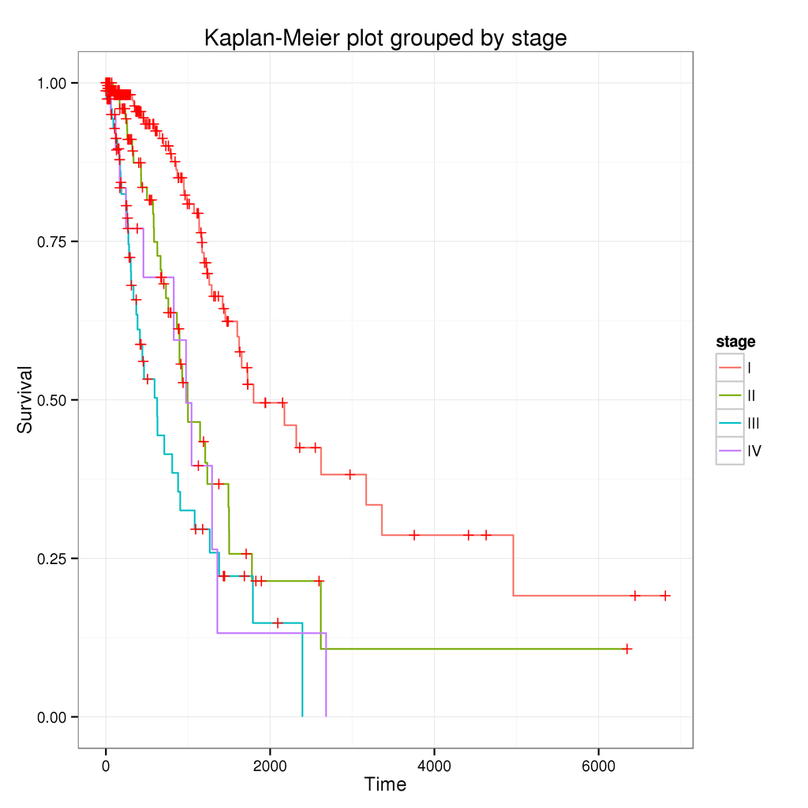

```r
metadata = km_metadata[km_metadata$stage != "[Not Available]", ]
levels(metadata$stage) = list(I = c("Stage I", "Stage IA", "Stage IB"), II = c("Stage II", "Stage IIA", "Stage IIB"), III = c("Stage III", "Stage IIIA", "Stage IIIB"), IV = "Stage IV")
km = survfit(Surv(days_survived, vital_status) ~ stage, data = metadata)
ggsurv(km) + theme_bw() + ggtitle("Kaplan-Meier plot grouped by stage")
```

```r
coxph(Surv(days_survived, vital_status) ~ stage, data = metadata)
```

```
## Call:
## coxph(formula = Surv(days_survived, vital_status) ~ stage, data = metadata)
##
##
##           coef exp(coef) se(coef)    z       p
## stageII  0.832     2.299    0.236 3.53 0.00042
## stageIII 1.481     4.396    0.234 6.33 2.4e-10
## stageIV  1.192     3.295    0.342 3.49 0.00049
##
## Likelihood ratio test=42.8  on 3 df, p=2.76e-09
## n= 492, number of events= 121
```

### Lymph node involvement

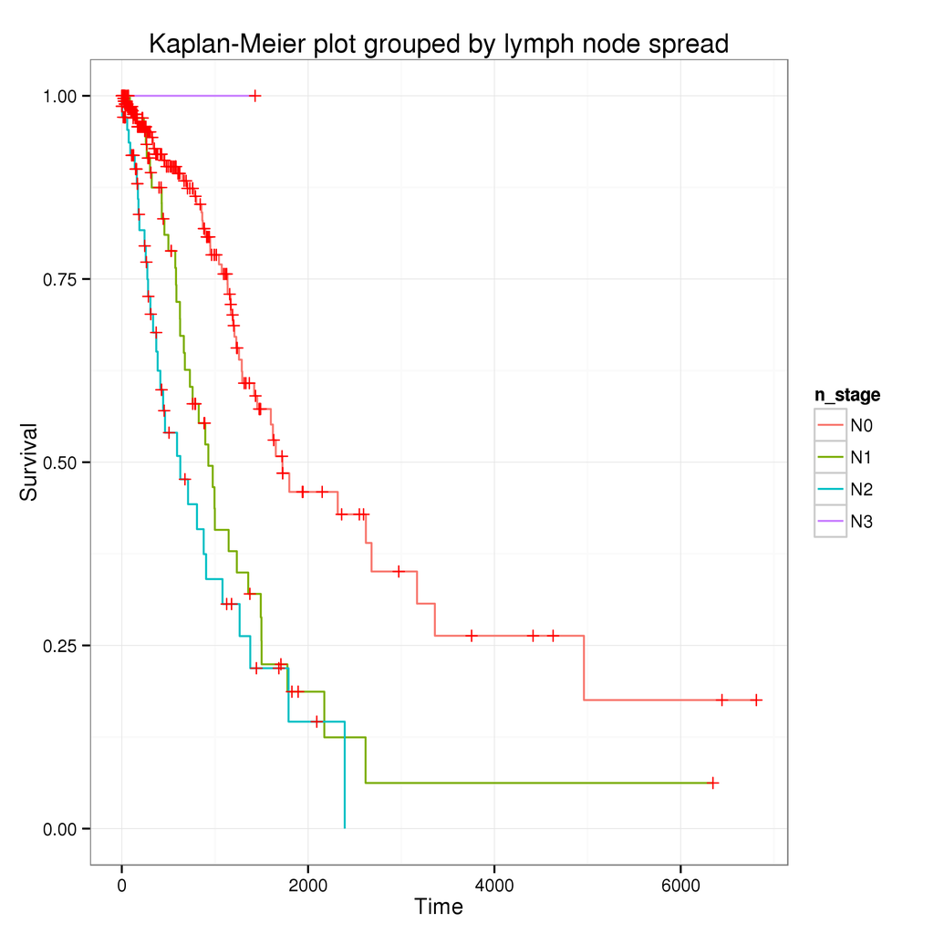

```r
metadata = km_metadata[km_metadata$n_stage %in% c("N0", "N1", "N2", "N3"), ]
metadata$n_stage = droplevels(metadata$n_stage)
km = survfit(Surv(days_survived, vital_status) ~ n_stage, data = metadata)
ggsurv(km) + theme_bw() + ggtitle("Kaplan-Meier plot grouped by lymph node spread")
```

```r
coxph(Surv(days_survived, vital_status) ~ n_stage, data = metadata)
```

```
## Call:
## coxph(formula = Surv(days_survived, vital_status) ~ n_stage,
##     data = metadata)
##
##
##                coef exp(coef)  se(coef)     z       p
## n_stageN1  8.37e-01  2.31e+00  2.20e-01  3.80 0.00014
## n_stageN2  1.30e+00  3.67e+00  2.29e-01  5.69 1.3e-08
## n_stageN3 -1.48e+01  3.83e-07  2.29e+03 -0.01 0.99486
##
## Likelihood ratio test=35.4  on 3 df, p=1.02e-07
## n= 481, number of events= 119
```

### Metastasis

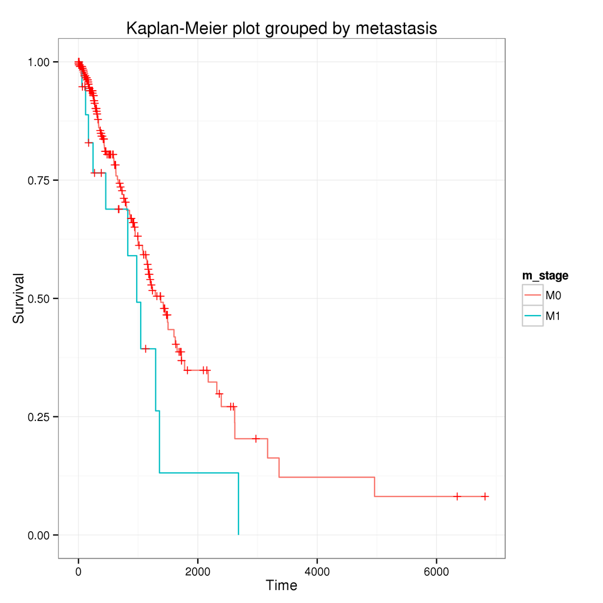

```r
metadata = km_metadata[km_metadata$m_stage %in% c("M0", "M1", "M1a", "M1b"), ]
levels(metadata$m_stage) = list(M0 = "M0", M1 = c("M1", "M1a", "M1b"))
km = survfit(Surv(days_survived, vital_status) ~ m_stage, data = metadata)
ggsurv(km) + theme_bw() + ggtitle("Kaplan-Meier plot grouped by metastasis")
```

```r
summary(coxph(Surv(days_survived, vital_status) ~ m_stage, data = metadata))
```

```
## Call:
## coxph(formula = Surv(days_survived, vital_status) ~ m_stage,
##     data = metadata)
##
##   n= 349, number of events= 100
##
##             coef exp(coef) se(coef)     z Pr(>|z|)
## m_stageM1 0.5819    1.7895   0.3214 1.811   0.0702 .
## ---
## Signif. codes:  0 '***' 0.001 '**' 0.01 '*' 0.05 '.' 0.1 ' ' 1
##
##           exp(coef) exp(-coef) lower .95 upper .95
## m_stageM1      1.79     0.5588    0.9532      3.36
##
## Concordance= 0.524  (se = 0.015 )
## Rsquare= 0.008   (max possible= 0.921 )
## Likelihood ratio test= 2.83  on 1 df,   p=0.09252
## Wald test            = 3.28  on 1 df,   p=0.07019
## Score (logrank) test = 3.37  on 1 df,   p=0.06633
```

### Smoker vs non-smoker

```r
coxph(Surv(days_survived, vital_status) ~ smoker, data = km_metadata)
```

```
## Call:
## coxph(formula = Surv(days_survived, vital_status) ~ smoker, data = km_metadata)
##
##
##          coef exp(coef) se(coef)     z    p
## smoker -0.107     0.899    0.294 -0.36 0.72
##
## Likelihood ratio test=0.13  on 1 df, p=0.72
## n= 493, number of events= 121
```

### Gender

```r
coxph(Surv(days_survived, vital_status) ~ gender, data = km_metadata)
```

```
## Call:
## coxph(formula = Surv(days_survived, vital_status) ~ gender, data = km_metadata)
##
##
##              coef exp(coef) se(coef)     z    p
## genderMALE -0.102     0.903    0.184 -0.56 0.58
##
## Likelihood ratio test=0.31  on 1 df, p=0.578
## n= 493, number of events= 121
```

### Race

```r
metadata = km_metadata
levels(metadata$race) = list(White = "WHITE", Black = "BLACK OR AFRICAN AMERICAN", Asian = "ASIAN", Unknown = c("[Not Available", "[Not Evaluated]", "[Unknown]"))
km = survfit(Surv(days_survived, vital_status) ~ race, data = metadata)
coxph(Surv(days_survived, vital_status) ~ race, data = metadata)
```

```
## Call:
## coxph(formula = Surv(days_survived, vital_status) ~ race, data = metadata)
##
##
##                  coef exp(coef)  se(coef)     z    p
## raceBlack   -4.71e-01  6.24e-01  3.12e-01 -1.51 0.13
## raceAsian   -1.61e+01  1.02e-07  2.27e+03 -0.01 0.99
## raceUnknown -4.31e-02  9.58e-01  3.80e-01 -0.11 0.91
##
## Likelihood ratio test=6.12  on 3 df, p=0.106
## n= 456, number of events= 112
##    (37 observations deleted due to missingness)
```

### Age

```r
metadata = km_metadata
metadata$age = ifelse(as.integer(as.character(metadata$age)) <= 65, "<= 65", "> 65")
km = survfit(Surv(days_survived, vital_status) ~ age, data = metadata)
coxph(Surv(days_survived, vital_status) ~ age, data = metadata)
```

```
## Call:
## coxph(formula = Surv(days_survived, vital_status) ~ age, data = metadata)
##
##
##          coef exp(coef) se(coef)    z    p
## age> 65 0.291     1.337    0.186 1.56 0.12
##
## Likelihood ratio test=2.48  on 1 df, p=0.116
## n= 493, number of events= 121
```

Out of all of these, only lymph node involvement and cancer stage are significant predictors of survival.

## Univariate survival analyses for features

```r
metadata = luad_metadata[luad_metadata$sample_type == "TP" & !is.na(luad_metadata$days_survived) & luad_metadata$days_survived > 0, ]
counts = luad_adjusted_counts[rownames(luad_adjusted_counts) %in% srnas[srnas$class %in% c("tRF-1", "tRF-3", "tRF-5", "miRNA")]$tx_name, colnames(luad_adjusted_counts) %in% metadata$barcode]
metadata$dummy = as.factor(1)
dataset = setupTrainingTestingSets(metadata, "dummy", counts)
features = rownames(counts)
hazard_ratios = data.frame(t(sapply(features, function(feature) {
  training_counts = t(dataset$training_counts)[, feature]
  training_metadata = cbind(dataset$training_metadata, feature = training_counts)
  cox = summary(coxph(Surv(days_survived, vital_status) ~ feature, data = training_metadata))
  hazard = cox$conf.int[1]
  conf_int = cox$conf.int[3:4]
  pval = coef(cox)[5]
  c(hazard, conf_int, pval)
  })))
colnames(hazard_ratios) = c('hazard', 'lower', 'upper', 'pvalue')
```

We have `299` features that are significant (p < 0.05), with `165` miRNAs and `134` tRNA fragments.

## Identify signatures

```r
mirna_signature = hazard_ratios[str_detect(rownames(hazard_ratios), "hsa-mir|hsa-let"), ]
mirna_signature = mirna_signature[order(mirna_signature$pvalue), ][1:20, ]
kable(mirna_signature)
```

|  | hazard | lower | upper | pvalue |
| --- | --- | --- | --- | --- |
| hsa-mir-548f-1 | 1.051505 | 1.031358 | 1.072046 | 0.0000004 |
| hsa-mir-1293 | 1.019581 | 1.011057 | 1.028177 | 0.0000060 |
| hsa-mir-1910 | 1.132262 | 1.071833 | 1.196099 | 0.0000090 |
| hsa-mir-548ba | 1.503327 | 1.252180 | 1.804846 | 0.0000124 |
| hsa-mir-548h-3 | 1.485293 | 1.231547 | 1.791322 | 0.0000349 |
| hsa-mir-4746 | 1.024284 | 1.012601 | 1.036102 | 0.0000414 |
| hsa-mir-548n | 1.150688 | 1.075951 | 1.230616 | 0.0000419 |
| hsa-mir-607 | 1.335300 | 1.160067 | 1.537003 | 0.0000561 |
| hsa-mir-5685 | 1.672114 | 1.288098 | 2.170614 | 0.0001126 |
| hsa-mir-548ab | 1.351687 | 1.156797 | 1.579412 | 0.0001485 |
| hsa-mir-3662 | 1.216051 | 1.096312 | 1.348868 | 0.0002168 |
| hsa-mir-7974 | 1.246340 | 1.105680 | 1.404894 | 0.0003131 |
| hsa-mir-4528 | 1.954223 | 1.355571 | 2.817255 | 0.0003305 |
| hsa-mir-4538 | 3.306484 | 1.688782 | 6.473797 | 0.0004856 |
| hsa-mir-1304 | 1.002804 | 1.001213 | 1.004398 | 0.0005478 |
| hsa-mir-4661 | 1.010709 | 1.004540 | 1.016916 | 0.0006499 |
| hsa-mir-3690-1 | 1.036211 | 1.015224 | 1.057630 | 0.0006559 |
| hsa-mir-3690-2 | 1.036211 | 1.015224 | 1.057630 | 0.0006559 |
| hsa-mir-1915 | 1.385374 | 1.148481 | 1.671130 | 0.0006571 |
| hsa-mir-7851 | 1.208027 | 1.081869 | 1.348896 | 0.0007844 |

```r
tsrna_signature = hazard_ratios[str_detect(rownames(hazard_ratios), "tRF|trailer"), ]
tsrna_signature = tsrna_signature[order(tsrna_signature$pvalue), ][1:20, ]
kable(tsrna_signature)
```

|  | hazard | lower | upper | pvalue |
| --- | --- | --- | --- | --- |
| tRNA-AlaTGC3-tRF-3 | 1.027952 | 1.017407 | 1.038606 | 0.0000002 |
| tRNA-AlaAGC23-tRF-3 | 1.002196 | 1.001352 | 1.003041 | 0.0000003 |
| tRNA-AlaTGC9-tRF-3 | 1.051584 | 1.031437 | 1.072125 | 0.0000003 |
| tRNA-AlaTGC4-tRF-3 | 1.050749 | 1.030625 | 1.071266 | 0.0000005 |
| tRNA-AspATC1-tRF-3 | 1.002562 | 1.001558 | 1.003566 | 0.0000005 |
| tRNA-AlaAGC3-tRF-3 | 1.016817 | 1.010162 | 1.023517 | 0.0000006 |
| tRNA-AlaAGC19-tRF-3 | 1.016994 | 1.010263 | 1.023769 | 0.0000007 |
| tRNA-LysTTT11-tRF-3 | 1.074730 | 1.043570 | 1.106821 | 0.0000016 |
| tRNA-LysTTT6-tRF-3 | 1.074272 | 1.043082 | 1.106393 | 0.0000019 |
| tRNA-LysTTT13-tRF-3 | 1.074272 | 1.043082 | 1.106393 | 0.0000019 |
| tRNA-Leu-AAG-1-3_trailer | 3.487930 | 2.034755 | 5.978930 | 0.0000055 |
| tRNA-SerGCT3-tRF-3 | 1.011988 | 1.006706 | 1.017297 | 0.0000081 |
| tRNA-TyrGTA20-tRF-3 | 1.002083 | 1.001155 | 1.003012 | 0.0000107 |
| tRNA-ThrTGT6-tRF-3 | 1.013570 | 1.007318 | 1.019861 | 0.0000196 |
| tRNA-Ser-GCT-4-3_trailer | 2.868269 | 1.730460 | 4.754207 | 0.0000437 |
| chr6_cox_hap2.tRNA44-SerGCT_trailer | 2.868269 | 1.730460 | 4.754207 | 0.0000437 |
| tRNA-Cys-GCA-2-4_trailer | 1.055043 | 1.027464 | 1.083362 | 0.0000735 |
| tRNA-LysTTT1-tRF-3 | 1.036158 | 1.018055 | 1.054584 | 0.0000783 |
| tRNA-Arg-ACG-2-3_trailer | 1.068003 | 1.033067 | 1.104121 | 0.0001057 |
| tRNA-AlaAGC16-tRF-3 | 1.161439 | 1.075394 | 1.254368 | 0.0001385 |

```r
srna_signature = hazard_ratios[order(hazard_ratios$pvalue), ][1:20, ]
kable(srna_signature)
```

|  | hazard | lower | upper | pvalue |
| --- | --- | --- | --- | --- |
| tRNA-AlaTGC3-tRF-3 | 1.027952 | 1.017407 | 1.038606 | 2.00e-07 |
| tRNA-AlaAGC23-tRF-3 | 1.002196 | 1.001352 | 1.003041 | 3.00e-07 |
| tRNA-AlaTGC9-tRF-3 | 1.051584 | 1.031437 | 1.072125 | 3.00e-07 |
| hsa-mir-548f-1 | 1.051505 | 1.031358 | 1.072046 | 4.00e-07 |
| tRNA-AlaTGC4-tRF-3 | 1.050749 | 1.030625 | 1.071266 | 5.00e-07 |
| tRNA-AspATC1-tRF-3 | 1.002562 | 1.001558 | 1.003566 | 5.00e-07 |
| tRNA-AlaAGC3-tRF-3 | 1.016817 | 1.010162 | 1.023517 | 6.00e-07 |
| tRNA-AlaAGC19-tRF-3 | 1.016994 | 1.010263 | 1.023769 | 7.00e-07 |
| tRNA-LysTTT11-tRF-3 | 1.074730 | 1.043570 | 1.106821 | 1.60e-06 |
| tRNA-LysTTT6-tRF-3 | 1.074272 | 1.043082 | 1.106393 | 1.90e-06 |
| tRNA-LysTTT13-tRF-3 | 1.074272 | 1.043082 | 1.106393 | 1.90e-06 |
| tRNA-Leu-AAG-1-3_trailer | 3.487930 | 2.034755 | 5.978930 | 5.50e-06 |
| hsa-mir-1293 | 1.019581 | 1.011057 | 1.028177 | 6.00e-06 |
| tRNA-SerGCT3-tRF-3 | 1.011988 | 1.006706 | 1.017297 | 8.10e-06 |
| hsa-mir-1910 | 1.132262 | 1.071833 | 1.196099 | 9.00e-06 |
| tRNA-TyrGTA20-tRF-3 | 1.002083 | 1.001155 | 1.003012 | 1.07e-05 |
| hsa-mir-548ba | 1.503327 | 1.252180 | 1.804846 | 1.24e-05 |
| tRNA-ThrTGT6-tRF-3 | 1.013570 | 1.007318 | 1.019861 | 1.96e-05 |
| hsa-mir-548h-3 | 1.485293 | 1.231547 | 1.791322 | 3.49e-05 |
| hsa-mir-4746 | 1.024284 | 1.012601 | 1.036102 | 4.14e-05 |

## Train signatures

```r
trainTestSignatures = function(dataset, features) {
  # build model
  training_counts = t(dataset$training_counts[rownames(dataset$training_counts) %in% features, ])
  training_response = Surv(dataset$training_metadata$days_survived, dataset$training_metadata$vital_status)
  model = cv.glmnet(training_counts, training_response, alpha = 1, nlambda = 250, family = "cox")
  plot(model) # plot lambdas
  plot(model$glmnet.fit, label = TRUE) # plot coefficient shrinkage

  # test model - predict 3 year survival rate on testing data
  testing_metadata = dataset$testing_metadata
  testing_counts = t(dataset$testing_counts[rownames(dataset$training_counts) %in% features, colnames(dataset$testing_counts) %in% testing_metadata$barcode])
  testing_response = as.factor(ifelse(testing_metadata$days_survived >= 1095, ">3", "<3")) # test 3 year survival rate
  pred = predict(model, newx = testing_counts, s = model$lambda.min)
  prob = prediction(-pred, testing_response) # flip signs because we trained with survival data, and a positive coefficient gives a higher risk of death
  perf = performance(prob, "tpr", "fpr")
  roc = data.frame(TPR = unlist(perf@y.values), FPR = unlist(perf@x.values))
  auc = unlist(performance(prob, "auc")@y.values)
  auc = round(auc, 3)

  # classify into high/low risk sets
  testing_metadata$risk = as.factor(ifelse(pred > median(pred), "High-risk", "Low-risk"))
  km = survfit(Surv(days_survived, vital_status) ~ risk, data = testing_metadata)
  km = ggsurv(km) + theme_bw() + ggtitle("Kaplan-Meier plot for risk based on signature")
  cox = coxph(Surv(days_survived, vital_status) ~ risk, data = testing_metadata)

  list(model = model, coef = coef(model, s = model$lambda.min), score = pred[, ], roc = roc, auc = auc, cox = summary(cox), km = km)
}
```

To get a sense of the data, let's look at all of the clinical covariates:

```r
c(table(dataset$training_metadata$stage), table(dataset$testing_metadata$stage))
```

```
## [Not Available]         Stage I        Stage IA        Stage IB
##               1               3              67              63
##        Stage II       Stage IIA       Stage IIB      Stage IIIA
##               1              25              26              38
##      Stage IIIB        Stage IV [Not Available]         Stage I
##               5               7               0               2
##        Stage IA        Stage IB        Stage II       Stage IIA
##              62              61               0              21
##       Stage IIB      Stage IIIA      Stage IIIB        Stage IV
##              40              29               5              17
```

```r
c(table(dataset$training_metadata$m_stage), table(dataset$testing_metadata$m_stage))
```

```
##              M0              M1             M1a             M1b
##             153               4               1               2
##              MX [Not Available]              M0              M1
##              72               4             158              11
##             M1a             M1b              MX [Not Available]
##               1               3              64               0
```

```r
c(table(dataset$training_metadata$n_stage), table(dataset$testing_metadata$n_stage))
```

```
##              N0              N1              N2              N3
##             149              46              37               0
## [Not Available]              NX              N0              N1
##               1               3             156              42
##              N2              N3 [Not Available]              NX
##              30               2               0               7
```

```r
c(table(ifelse(dataset$training_metadata$age > 65, ">65", "<=65")), table(ifelse(dataset$testing_metadata$age > 65, ">65", "<=65")))
```

```
## integer(0)
```

```r
c(table(dataset$training_metadata$gender), table(dataset$testing_metadata$gender))
```

```
## FEMALE   MALE FEMALE   MALE
##    123    113    130    107
```

```r
c(table(dataset$training_metadata$smoker), table(dataset$testing_metadata$smoker))
```

```
##   0   1   0   1
##  31 205  38 199
```

```r
c(table(dataset$training_metadata$race), table(dataset$testing_metadata$race))
```

```
##                     ASIAN BLACK OR AFRICAN AMERICAN
##                         3                        32
##           [Not Available]           [Not Evaluated]
##                        16                         1
##                 [Unknown]                     WHITE
##                         2                       182
##                     ASIAN BLACK OR AFRICAN AMERICAN
##                         5                        18
##           [Not Available]           [Not Evaluated]
##                        17                         5
##                 [Unknown]                     WHITE
##                         3                       189
```

### tsRNA signature performance

```r
tsrna = trainTestSignatures(dataset, rownames(tsrna_signature))
```

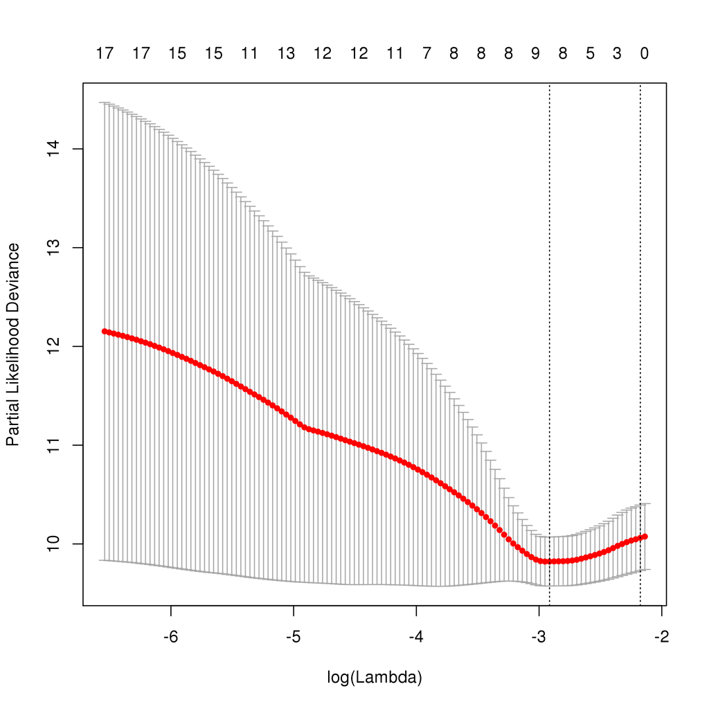

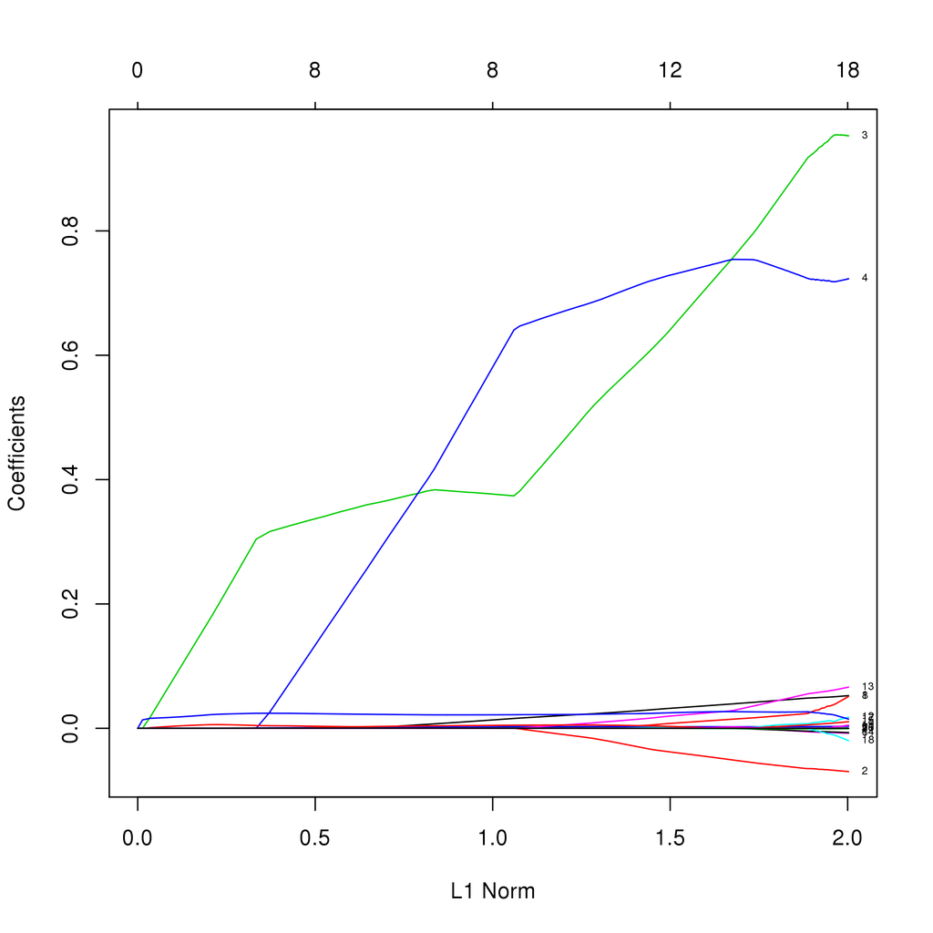

```r
tsrna$coef
```

```
## 20 x 1 sparse Matrix of class "dgCMatrix"
##                                                1
## tRNA-Arg-ACG-2-3_trailer            .
## tRNA-Cys-GCA-2-4_trailer            .
## tRNA-Leu-AAG-1-3_trailer            3.482942e-01
## tRNA-Ser-GCT-4-3_trailer            1.934168e-01
## chr6_cox_hap2.tRNA44-SerGCT_trailer 1.583424e-15
## tRNA-LysTTT1-tRF-3                  .
## tRNA-AlaAGC3-tRF-3                  .
## tRNA-AlaTGC3-tRF-3                  2.830928e-03
## tRNA-AspATC1-tRF-3                  .
## tRNA-AlaTGC4-tRF-3                  .
## tRNA-SerGCT3-tRF-3                  1.229208e-03
## tRNA-LysTTT6-tRF-3                  .
## tRNA-AlaAGC16-tRF-3                 .
## tRNA-ThrTGT6-tRF-3                  .
## tRNA-AlaTGC9-tRF-3                  1.901924e-03
## tRNA-TyrGTA20-tRF-3                 .
## tRNA-LysTTT11-tRF-3                 2.299503e-02
## tRNA-AlaAGC19-tRF-3                 .
## tRNA-LysTTT13-tRF-3                 .
## tRNA-AlaAGC23-tRF-3                 2.361321e-04
```

```r
coef(tsrna$cox)
```

```
##                    coef exp(coef)  se(coef)         z    Pr(>|z|)
## riskLow-risk -0.7181327  0.487662 0.2507016 -2.864492 0.004176788
```

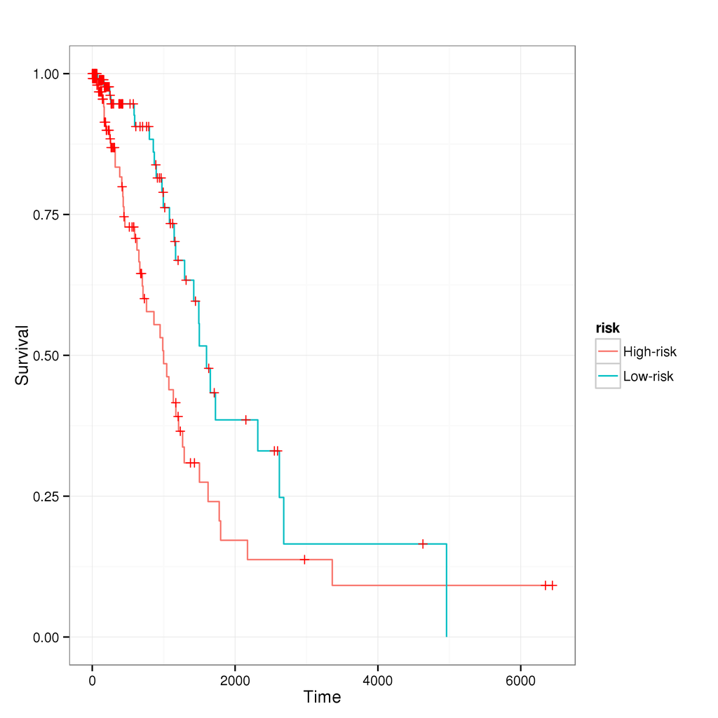

```r
tsrna$km + ggtitle("")
```

### microRNA signature performance

```r
mirna = trainTestSignatures(dataset, rownames(mirna_signature))
```

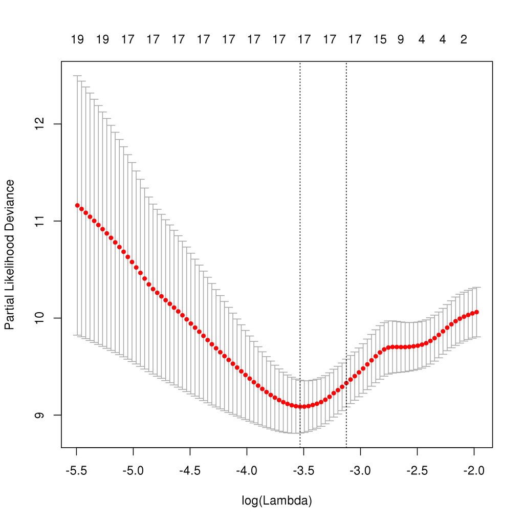

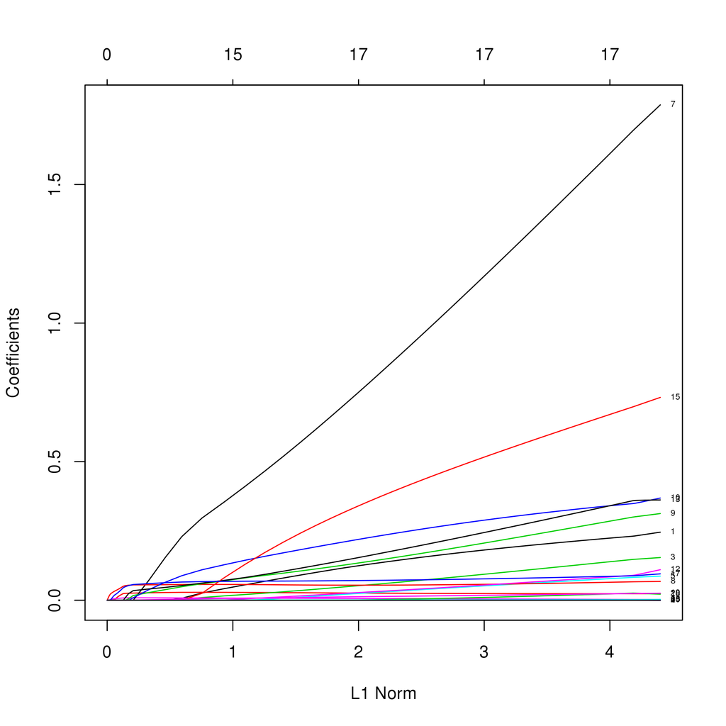

```r
mirna$coef
```

```
## 20 x 1 sparse Matrix of class "dgCMatrix"
##                           1
## hsa-mir-1915   1.757362e-01
## hsa-mir-548f-1 2.436529e-02
## hsa-mir-607    8.890256e-02
## hsa-mir-1304   .
## hsa-mir-7851   4.893389e-02
## hsa-mir-1293   4.985698e-03
## hsa-mir-4538   1.121806e+00
## hsa-mir-1910   5.685408e-02
## hsa-mir-548h-3 1.979250e-01
## hsa-mir-4528   2.821183e-01
## hsa-mir-4746   .
## hsa-mir-7974   5.164660e-02
## hsa-mir-548ba  2.340006e-01
## hsa-mir-548ab  .
## hsa-mir-5685   4.985534e-01
## hsa-mir-3662   8.880555e-03
## hsa-mir-548n   7.628612e-02
## hsa-mir-4661   1.475732e-03
## hsa-mir-3690-1 1.721400e-02
## hsa-mir-3690-2 2.526495e-16
```

```r
coef(mirna$cox)
```

```
##                    coef exp(coef)  se(coef)         z  Pr(>|z|)
## riskLow-risk -0.2732344 0.7609144 0.2475287 -1.103849 0.2696585
```

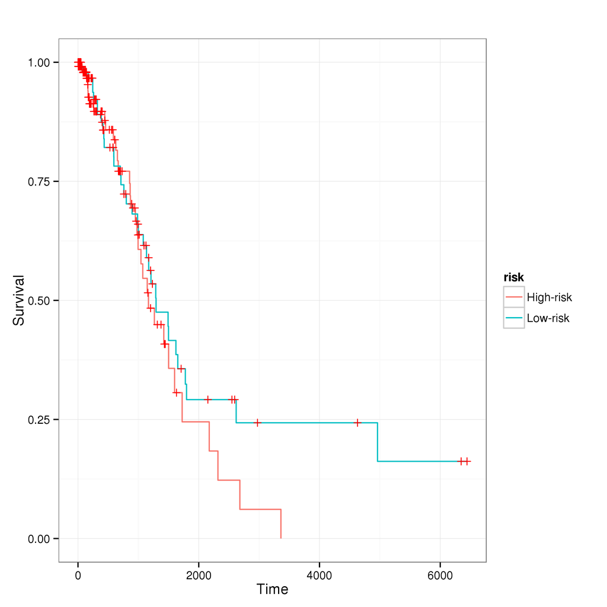

```r
mirna$km + ggtitle("")
```

### Combined signature performance

```r
srna = trainTestSignatures(dataset, rownames(srna_signature))
```

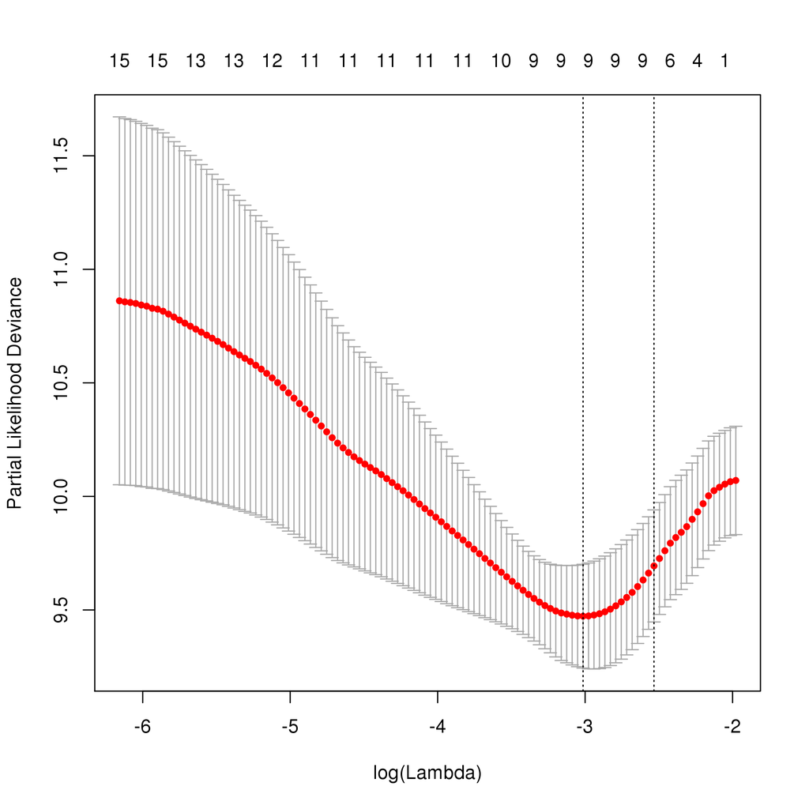

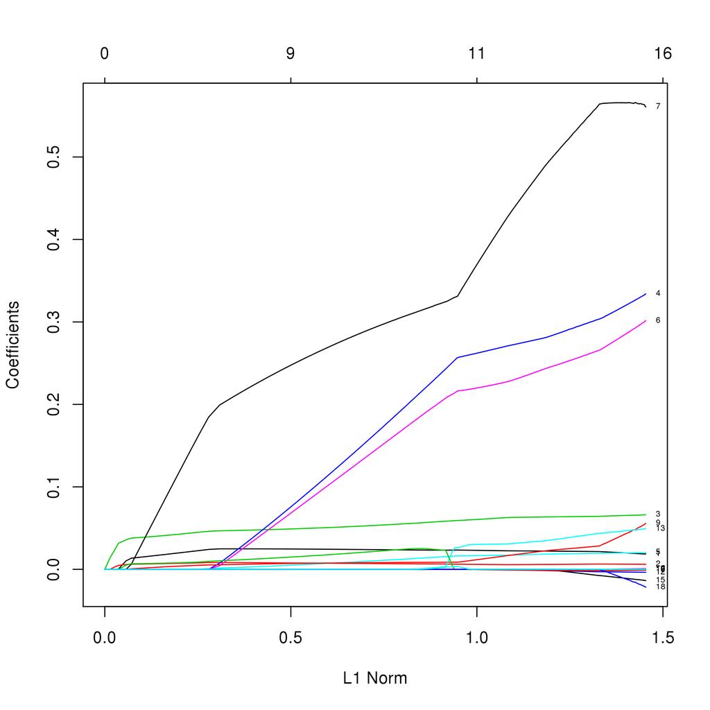

```r
srna$coef
```

```
## 20 x 1 sparse Matrix of class "dgCMatrix"
##                                    1
## hsa-mir-548f-1           0.024305564
## hsa-mir-1293             0.007383757
## hsa-mir-1910             0.051022066
## hsa-mir-548h-3           0.121577065
## hsa-mir-4746             0.007726061
## hsa-mir-548ba            0.108369776
## tRNA-Leu-AAG-1-3_trailer 0.273264150
## tRNA-AlaAGC3-tRF-3       .
## tRNA-AlaTGC3-tRF-3       0.007715852
## tRNA-AspATC1-tRF-3       .
## tRNA-AlaTGC4-tRF-3       .
## tRNA-SerGCT3-tRF-3       .
## tRNA-LysTTT6-tRF-3       .
## tRNA-ThrTGT6-tRF-3       .
## tRNA-AlaTGC9-tRF-3       .
## tRNA-TyrGTA20-tRF-3      .
## tRNA-LysTTT11-tRF-3      0.018307398
## tRNA-AlaAGC19-tRF-3      .
## tRNA-LysTTT13-tRF-3      .
## tRNA-AlaAGC23-tRF-3      .
```

```r
coef(srna$cox)
```

```
##                    coef exp(coef)  se(coef)         z   Pr(>|z|)
## riskLow-risk -0.5023741 0.6050924 0.2451411 -2.049326 0.04043022
```

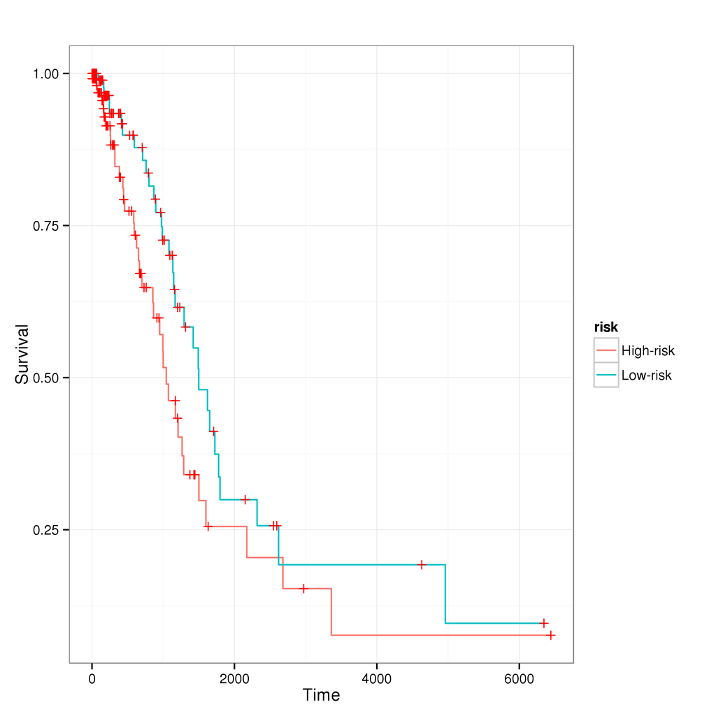

```r
srna$km + ggtitle("")
```

### Predicting 3-year survival

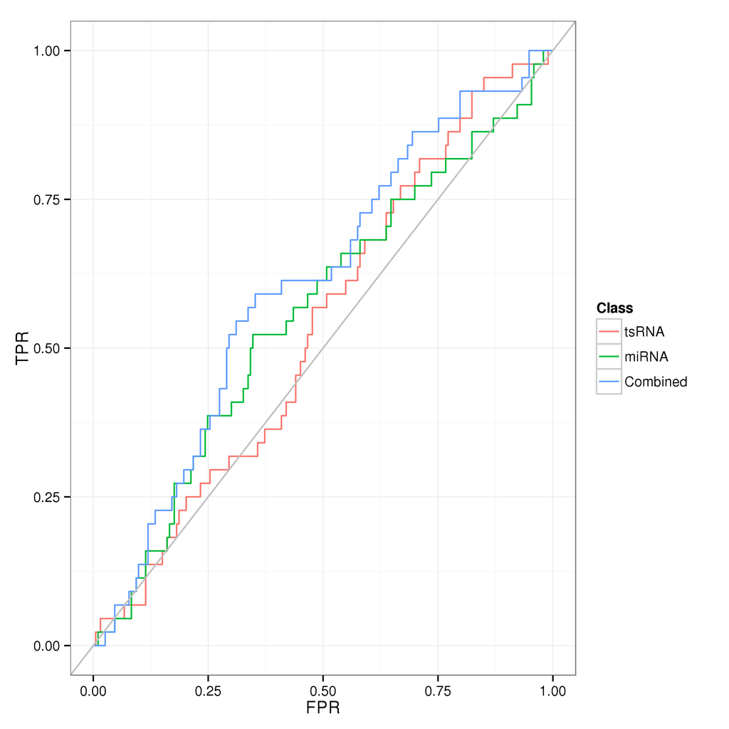

```r
roc = rbind(cbind(tsrna$roc, Class = "tsRNA"), cbind(mirna$roc, Class = "miRNA"), cbind(srna$roc, Class = "Combined"))
ggplot(roc) + geom_line(aes(x = FPR, y = TPR, color = Class)) + geom_abline(intercept = 0, slope = 1, colour = "gray") + ylab("TPR") + xlab("FPR") + theme_bw()
```

```r
c(tsRNA = tsrna$auc, miRNA = mirna$auc, sRNA = srna$auc)
```

```
## tsRNA miRNA  sRNA
## 0.536 0.559 0.605
```

## Multivariate survival analyses

Let's test whether this sRNA signature has prognostic value independent of stage and lymph node involvement. First, the univariate estimate:

```r
metadata = dataset$testing_metadata
metadata$score = srna$score
cox = coxph(Surv(days_survived, vital_status) ~ score, data = metadata)
kable(data.frame(Coef = cox$coef, Hazard = summary(cox)$conf.int[1], Lower = summary(cox)$conf.int[3], Upper = summary(cox)$conf.int[4], Pval = summary(cox)$coef[5]))
```

|  | Coef | Hazard | Lower | Upper | Pval |
| --- | --- | --- | --- | --- | --- |
| score | 0.5071831 | 1.660607 | 1.043058 | 2.64378 | 0.0325457 |

Then, let's see if stage is a confounding factor. If it is, then the confidence intervals should shrink (added precision), and the hazard ratio should appreciably change.

```r
metadata = metadata[metadata$stage != "[Not Available]", ]
levels(metadata$stage) = list(I = c("Stage I", "Stage IA", "Stage IB"), II = c("Stage II", "Stage IIA", "Stage IIB"), III = c("Stage III", "Stage IIIA", "Stage IIIB"), IV = "Stage IV")
cox = coxph(Surv(days_survived, vital_status) ~ score + stage, data = metadata)
kable(data.frame(Coef = cox$coef, Hazard = summary(cox)$conf.int[, 1], Lower = summary(cox)$conf.int[, 3], Upper = summary(cox)$conf.int[, 4], Pval = summary(cox)$coef[, 5]))
```

|  | Coef | Hazard | Lower | Upper | Pval |
| --- | --- | --- | --- | --- | --- |
| score | 0.5058385 | 1.658376 | 1.020763 | 2.694269 | 0.0410563 |
| stageII | 0.7087340 | 2.031418 | 1.133937 | 3.639232 | 0.0171953 |
| stageIII | 1.4435898 | 4.235875 | 2.104073 | 8.527574 | 0.0000526 |
| stageIV | 0.9566868 | 2.603058 | 1.170935 | 5.786750 | 0.0189195 |

By the way, since stage is a categorical variable, ANOVA can see whether stage is a significant covariate *after* adjustment for the effect of risk score. It's significant.

```r
anova(cox)
```

```
## Analysis of Deviance Table
##  Cox model: response is Surv(days_survived, vital_status)
## Terms added sequentially (first to last)
##
##        loglik   Chisq Df Pr(>|Chi|)
## NULL  -267.84
## score -265.90  3.8854  1  0.0487069 *
## stage -257.15 17.4919  3  0.0005598 ***
## ---
## Signif. codes:  0 '***' 0.001 '**' 0.01 '*' 0.05 '.' 0.1 ' ' 1
```

Now, we test if there's an interaction between score and stage.

```r
cox = coxph(Surv(days_survived, vital_status) ~ score + stage + score:stage, data = metadata)
kable(data.frame(Coef = cox$coef, Hazard = summary(cox)$conf.int[, 1], Lower = summary(cox)$conf.int[, 3], Upper = summary(cox)$conf.int[, 4], Pval = summary(cox)$coef[, 5]))
```

|  | Coef | Hazard | Lower | Upper | Pval |
| --- | --- | --- | --- | --- | --- |
| score | 0.1467692 | 1.1580866 | 0.4516002 | 2.969805 | 0.7600140 |
| stageII | 0.2719289 | 1.3124937 | 0.3142204 | 5.482265 | 0.7092869 |
| stageIII | -0.2898709 | 0.7483602 | 0.0484910 | 11.549422 | 0.8355305 |
| stageIV | -0.1479331 | 0.8624889 | 0.0488351 | 15.232640 | 0.9195685 |
| score:stageII | 0.3840784 | 1.4682605 | 0.4700851 | 4.585954 | 0.5086384 |
| score:stageIII | 1.4574209 | 4.2948685 | 0.4921986 | 37.476531 | 0.1873002 |
| score:stageIV | 0.9263771 | 2.5253435 | 0.2702756 | 23.595763 | 0.4165099 |

The interaction term is not significant, so we can safely say there's no interaction.

```r
metadata = dataset$testing_metadata
metadata$score = tsrna$score
metadata = metadata[metadata$n_stage %in% c("N0", "N1", "N2", "N3"), ]
metadata$n_stage = droplevels(metadata$n_stage)
cox = coxph(Surv(days_survived, vital_status) ~ score + n_stage, data = metadata)
kable(data.frame(Coef = cox$coef, Hazard = summary(cox)$conf.int[, 1], Lower = summary(cox)$conf.int[, 3], Upper = summary(cox)$conf.int[, 4], Pval = summary(cox)$coef[, 5]))
```

|  | Coef | Hazard | Lower | Upper | Pval |
| --- | --- | --- | --- | --- | --- |
| score | 0.8071364 | 2.2414801 | 1.2094673 | 4.154087 | 0.0103434 |
| n_stageN1 | 0.5578615 | 1.7469327 | 0.9826666 | 3.105604 | 0.0573808 |
| n_stageN2 | 1.5823994 | 4.8666189 | 2.5082387 | 9.442475 | 0.0000029 |
| n_stageN3 | -15.4463424 | 0.0000002 | 0.0000000 | Inf | 0.9953865 |

```r
anova(cox)
```

```
## Analysis of Deviance Table
##  Cox model: response is Surv(days_survived, vital_status)
## Terms added sequentially (first to last)
##
##          loglik   Chisq Df Pr(>|Chi|)
## NULL    -258.26
## score   -255.33  5.8552  1  0.0155311 *
## n_stage -244.90 20.8537  3  0.0001129 ***
## ---
## Signif. codes:  0 '***' 0.001 '**' 0.01 '*' 0.05 '.' 0.1 ' ' 1
```

```r
cox = coxph(Surv(days_survived, vital_status) ~ score + n_stage + score:n_stage, data = metadata)
kable(data.frame(Coef = cox$coef, Hazard = summary(cox)$conf.int[, 1], Lower = summary(cox)$conf.int[, 3], Upper = summary(cox)$conf.int[, 4], Pval = summary(cox)$coef[, 5]))
```

|  | Coef | Hazard | Lower | Upper | Pval |
| --- | --- | --- | --- | --- | --- |
| score | 0.8838405 | 2.4201766 | 0.8971015 | 6.529088 | 0.0808953 |
| n_stageN1 | 1.3460770 | 3.8423224 | 0.8791027 | 16.793761 | 0.0736572 |
| n_stageN2 | 0.5699220 | 1.7681292 | 0.3547109 | 8.813602 | 0.4868226 |
| n_stageN3 | -16.0264304 | 0.0000001 | 0.0000000 | Inf | 0.9999480 |
| score:n_stageN1 | -0.8901903 | 0.4105776 | 0.0802494 | 2.100625 | 0.2851584 |
| score:n_stageN2 | 1.0615918 | 2.8909692 | 0.6286885 | 13.293870 | 0.1726477 |
| score:n_stageN3 | -0.2777357 | 0.7574970 | 0.0000000 | Inf | 0.9999989 |

## Visualizations

### Risk scores for sRNA signature

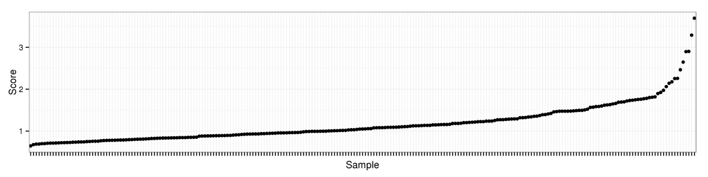

```r
df = data.frame(Sample = as.character(dataset$testing_metadata$barcode), Score = srna$score, stringsAsFactors = FALSE)
df = df[order(df$Score), ]
df$Sample = factor(df$Sample, levels = df$Sample)
ggplot(df) + geom_point(aes(x = Sample, y = Score)) + theme(axis.text.x = element_blank())
```

### Expression heatmaps

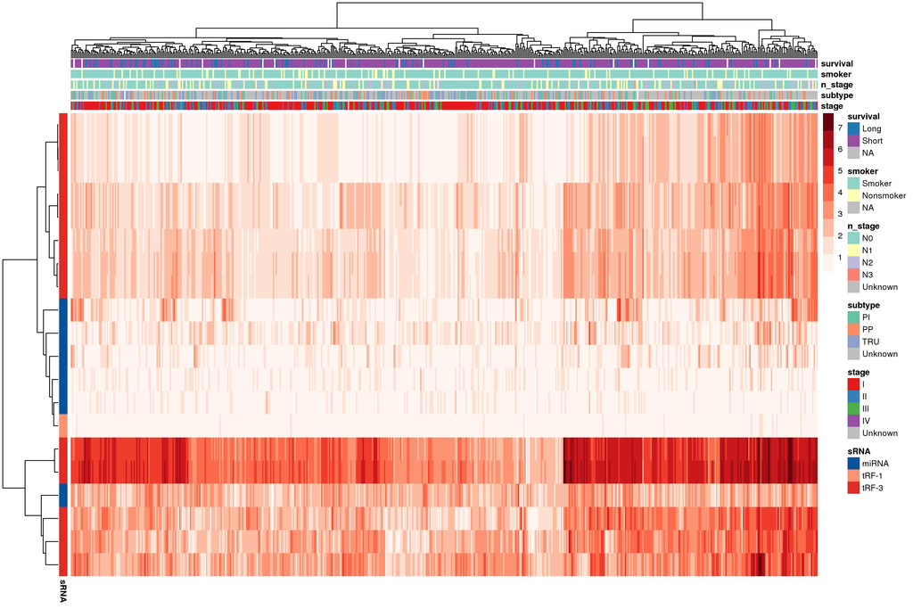

```r
df = log1p(as.matrix(luad_adjusted_counts[rownames(luad_adjusted_counts) %in% rownames(hazard_ratios[rownames(hazard_ratios) %in% rownames(srna_signature), ]), ]))
heatmap_metadata = luad_metadata[luad_metadata$barcode %in% colnames(df), ]
# subtype
load('/inside/grotto/blin/trna-markers/luad/cluster-subtypes/clusters.RData')
clusters$subtype[!clusters$known] = "Unknown"
heatmap_metadata$subtype = as.factor(clusters$subtype[match(substr(heatmap_metadata$barcode, 1, 12), clusters$barcode)])
# stage
levels(heatmap_metadata$stage) = list(I = c("Stage I", "Stage IA", "Stage IB"), II = c("Stage II", "Stage IIA", "Stage IIB"), III = c("Stage III", "Stage IIIA", "Stage IIIB"), IV = "Stage IV", Unknown = '[Not Available]')
# n stage
levels(heatmap_metadata$n_stage) = list(N0 = "N0", N1 = "N1", N2 = "N2", N3 = "N3", Unknown = c("NX", "[Not Available]"))
# smoker
heatmap_metadata$smoker = as.factor(heatmap_metadata$smoker)
levels(heatmap_metadata$smoker) = list(Smoker = 1, Nonsmoker = 0)
# survival
heatmap_metadata$survival = as.factor(heatmap_metadata$days_survived > 1000)
levels(heatmap_metadata$survival) = list(Long = TRUE, Short = FALSE)
# heatmap annotation
annot_col = data.frame(stage = heatmap_metadata$stage, subtype = heatmap_metadata$subtype, n_stage = heatmap_metadata$n_stage, smoker = heatmap_metadata$smoker, survival = heatmap_metadata$survival)
rownames(annot_col) = colnames(df)
annot_row = data.frame(sRNA = as.factor(srnas[match(rownames(df), srnas$tx_name), ]$class))
rownames(annot_row) = rownames(df)
annot_colors = list(stage = setNames(c(brewer.pal(4, "Set1"), "grey"), levels(heatmap_metadata$stage)),
                    subtype = setNames(c(brewer.pal(3, "Set2"), "grey"), levels(heatmap_metadata$subtype)),
                    n_stage = setNames(c(brewer.pal(4, "Set3"), "grey"), levels(heatmap_metadata$n_stage)),
                    smoker = setNames(c("#8dd3c7", "#ffffb3", "grey"), levels(heatmap_metadata$smoker)),
                    survival = setNames(c("#1f78b4", "#984ea3", "grey"), levels(heatmap_metadata$survival)),
                    sRNA = setNames(c("#08519c", "#fc9272", "#de2d26"), levels(annot_row$sRNA)))
pheatmap(df, annotation_col = annot_col, annotation_row = annot_row, annotation_colors = annot_colors, fontsize = 8,  show_colnames = FALSE, show_rownames = FALSE, trace = "none", color = brewer.pal(9, "Reds"))
```

## Multiple trials

We want to use multiple trials for two purposes: a) measure the robustness, and b) perform feature selection. It's true that the features will be trained on all of the data, but we don't care about that - the validation occurs downstream with experiments and external data.

```r
runTrial = function(dataset, features) {
  # feature selection: coxph -> hazard ratios
  hazard_ratios = data.frame(t(sapply(features, function(feature) {
    training_counts = t(dataset$training_counts)[, feature]
    training_metadata = cbind(dataset$training_metadata, feature = training_counts)
    cox = summary(coxph(Surv(days_survived, vital_status) ~ feature, data = training_metadata))
    hazard = cox$conf.int[1]
    lower = cox$conf.int[3]
    upper = cox$conf.int[4]
    pvalue = coef(cox)[5]
    c(hazard = hazard, lower = lower, upper = upper, pvalue = pvalue)
  })))

  mirna_hazards = hazard_ratios[str_detect(rownames(hazard_ratios), "hsa-mir|hsa-let"), ]
  mirna_hazards = mirna_hazards[order(mirna_hazards$pvalue), ][1:20, ]
  tsrna_hazards = hazard_ratios[str_detect(rownames(hazard_ratios), "tRF|trailer"), ]
  tsrna_hazards = tsrna_hazards[order(tsrna_hazards$pvalue), ][1:20, ]
  srna_hazards = hazard_ratios[order(hazard_ratios$pvalue), ][1:20, ]

  signaturePvals = lapply(list(mirna_hazards, tsrna_hazards, srna_hazards), function(hazards) {
    # feature selection: build model with lasso
    training_response = Surv(dataset$training_metadata$days_survived, dataset$training_metadata$vital_status)
    training_counts = t(dataset$training_counts[rownames(dataset$training_counts) %in% rownames(hazards), ])
    model = cv.glmnet(training_counts, training_response, alpha = 1, nlambda = 250, family = "cox")
    # test model - split into high vs low risk, and find significance of risk score
    testing_metadata = dataset$testing_metadata
    testing_counts = t(dataset$testing_counts[rownames(dataset$training_counts) %in% rownames(hazards), colnames(dataset$testing_counts) %in% testing_metadata$barcode])
    pred = predict(model, newx = testing_counts, s = model$lambda.min)
    testing_metadata$risk = as.factor(ifelse(pred > median(pred), "High-risk", "Low-risk"))
    cox = coxph(Surv(days_survived, vital_status) ~ risk, data = testing_metadata)
    list(pval = coef(summary(cox))[5], signature = rownames(coef(model, s = model$lambda.min)))
  })

  list(mirna_pval = signaturePvals[[1]]$pval, mirna_signature = signaturePvals[[1]]$signature, tsrna_pval = signaturePvals[[2]]$pval, tsrna_signature = signaturePvals[[2]]$signature, srna_pval = signaturePvals[[3]]$pval, srna_signature = signaturePvals[[3]]$signature)
}
```

### Remove redundant sRNAs

There's a lot of tRFs that are basically the same feature, just derived from different tRNAs. I've identified a few of them and reduced the number of tRF features from 1311 to 1046. This isn't all of the duplicates - for example, if we have two identical sequences except for one being 1 base pair longer, it won't match.

```r
unique_trfs = read.table('~/grotto/data/hg19-unique-tRFs.bed', header = FALSE, stringsAsFactors = FALSE)
unique_trfs = GRanges(unique_trfs$V1, IRanges(unique_trfs$V2, unique_trfs$V3), unique_trfs$V6, tx_name = unique_trfs$V4, class = as.factor(unique_trfs$V5))
unique_srnas = c(srnas[srnas$class == "miRNA"], unique_trfs)
```

```r
ntrials = 1000
trials = mclapply(1:ntrials, function(i) {
  metadata = luad_metadata[luad_metadata$sample_type == "TP" & !is.na(luad_metadata$days_survived) & luad_metadata$days_survived > 0, ]
  counts = luad_adjusted_counts[rownames(luad_adjusted_counts) %in% unique_srnas$tx_name, colnames(luad_adjusted_counts) %in% metadata$barcode]
  metadata$dummy = as.factor(1)
  dataset = setupTrainingTestingSets(metadata, "dummy", counts)
  runTrial(dataset, rownames(counts))
}, mc.cores = 25)
```

We've already run the trials, so what we need to do now is extract p-values and check out the features that have been selected the most. To assess significance, the null hypothesis is that each feature has an equal chance of being selected.

This can be modeled as a binomial distribution *B*(*n*, *p*), where *n* is the number of trials and *p* is the probability of being selected. In this case, *p* is `20/(# features)`, since in the Cox model we default to the 20 most significant hazard ratios. The mean, *np*, is quite intuitive: it's the probability of a feature being selected times the number of trials, so at random we can expect a feature to be selected *np* times. We derive the variance from the distribution, *npq*.

The p-value is calculated by first calculating the z-score and then using `pnorm`.

```r
# Some trials will fail and exit silently, need to catch these and remove them
pvals = ldply(trials, function(trial) tryCatch(c(miRNA = trial$mirna_pval, tRF = trial$tsrna_pval, sRNA = trial$srna_pval), error = function(e) c(miRNA = NA, tRF = NA, sRNA = NA)))
trials = trials[complete.cases(pvals)]
pvals = pvals[complete.cases(pvals), ]
ntrials = sum(complete.cases(pvals))
srna_freq = rbind(data.frame(Class = 'miRNA', count(unlist(lapply(trials, function(trial) trial$mirna_signature)))),
                  data.frame(Class = 'tRF', count(unlist(lapply(trials, function(trial) trial$tsrna_signature)))),
                  data.frame(Class = 'sRNA', count(unlist(lapply(trials, function(trial) trial$srna_signature)))))
srna_freq$pval = (srna_freq$freq - ntrials * 20/dim(counts)[1])/(ntrials * 20/dim(counts)[1] * (1 - 20/dim(counts)[1]))
srna_freq$pval = pnorm(srna_freq$pval, lower.tail = FALSE)
srna_freq$padj = qvalue(srna_freq$pval) # only works for really large ntrials values
```

```
## [1] "ERROR: The estimated pi0 <= 0. Check that you have valid p-values or use another lambda method."
```

```r
srna_freq$bonf = srna_freq$pval < 0.05/dim(srna_freq)[1] # Bonferroni correction
srna_freq = srna_freq[order(srna_freq$freq, decreasing = TRUE), ]
kable(srna_freq[srna_freq$Class == "tRF", ][1:20, ])
```

|  | Class | x | freq | pval | padj | bonf |
| --- | --- | --- | --- | --- | --- | --- |
| 454 | tRF | tRNA-AlaTGC9-tRF-3 | 193 | 0 | 0 | TRUE |
| 449 | tRF | tRNA-AlaTGC4-tRF-3 | 191 | 0 | 0 | TRUE |
| 447 | tRF | tRNA-AlaTGC3-tRF-3 | 172 | 0 | 0 | TRUE |
| 441 | tRF | tRNA-AlaAGC3-tRF-3 | 169 | 0 | 0 | TRUE |
| 576 | tRF | tRNA-PheGAA10-tRF-i | 168 | 0 | 0 | TRUE |
| 434 | tRF | tRNA-AlaAGC19-tRF-3 | 165 | 0 | 0 | TRUE |
| 612 | tRF | tRNA-ThrTGT6-tRF-3 | 162 | 0 | 0 | TRUE |
| 438 | tRF | tRNA-AlaAGC23-tRF-3 | 135 | 0 | 0 | TRUE |
| 431 | tRF | tRNA-AlaAGC16-tRF-3 | 125 | 0 | 0 | TRUE |
| 597 | tRF | tRNA-SerGCT3-tRF-3 | 123 | 0 | 0 | TRUE |
| 565 | tRF | tRNA-LysTTT10-tRF-3 | 122 | 0 | 0 | TRUE |
| 604 | tRF | tRNA-ThrAGT5-tRF-3 | 115 | 0 | 0 | TRUE |
| 498 | tRF | tRNA-GlnCTG7-tRF-i | 106 | 0 | 0 | TRUE |
| 566 | tRF | tRNA-LysTTT11-tRF-3 | 106 | 0 | 0 | TRUE |
| 602 | tRF | tRNA-SupTTA1-tRF-i | 105 | 0 | 0 | TRUE |
| 482 | tRF | tRNA-AspATC1-tRF-3 | 97 | 0 | 0 | TRUE |
| 622 | tRF | tRNA-TyrGTA20-tRF-3 | 86 | 0 | 0 | TRUE |
| 549 | tRF | tRNA-LysCTT13-tRF-3 | 70 | 0 | 0 | TRUE |
| 578 | tRF | tRNA-PheGAA1-tRF-i | 68 | 0 | 0 | TRUE |
| 598 | tRF | tRNA-SerGCT4-tRF-3 | 65 | 0 | 0 | TRUE |

```r
kable(srna_freq[srna_freq$Class == "miRNA", ][1:20, ])
```

|  | Class | x | freq | pval | padj | bonf |
| --- | --- | --- | --- | --- | --- | --- |
| 38 | miRNA | hsa-mir-1293 | 175 | 0 | 0 | TRUE |
| 297 | miRNA | hsa-mir-548h-3 | 120 | 0 | 0 | TRUE |
| 299 | miRNA | hsa-mir-548h-5 | 86 | 0 | 0 | TRUE |
| 53 | miRNA | hsa-mir-1910 | 85 | 0 | 0 | TRUE |
| 26 | miRNA | hsa-mir-1269b | 83 | 0 | 0 | TRUE |
| 295 | miRNA | hsa-mir-548h-1 | 83 | 0 | 0 | TRUE |
| 293 | miRNA | hsa-mir-548f-1 | 82 | 0 | 0 | TRUE |
| 176 | miRNA | hsa-mir-4643 | 80 | 0 | 0 | TRUE |
| 318 | miRNA | hsa-mir-582 | 73 | 0 | 0 | TRUE |
| 13 | miRNA | hsa-mir-1245a | 67 | 0 | 0 | TRUE |
| 244 | miRNA | hsa-mir-5092 | 66 | 0 | 0 | TRUE |
| 298 | miRNA | hsa-mir-548h-4 | 59 | 0 | 0 | TRUE |
| 394 | miRNA | hsa-mir-7641-2 | 55 | 0 | 0 | TRUE |
| 148 | miRNA | hsa-mir-4435-1 | 54 | 0 | 0 | TRUE |
| 150 | miRNA | hsa-mir-4440 | 54 | 0 | 0 | TRUE |
| 113 | miRNA | hsa-mir-3656 | 53 | 0 | 0 | TRUE |
| 149 | miRNA | hsa-mir-4435-2 | 53 | 0 | 0 | TRUE |
| 323 | miRNA | hsa-mir-6087 | 52 | 0 | 0 | TRUE |
| 411 | miRNA | hsa-mir-873 | 46 | 0 | 0 | TRUE |
| 413 | miRNA | hsa-mir-876 | 43 | 0 | 0 | TRUE |

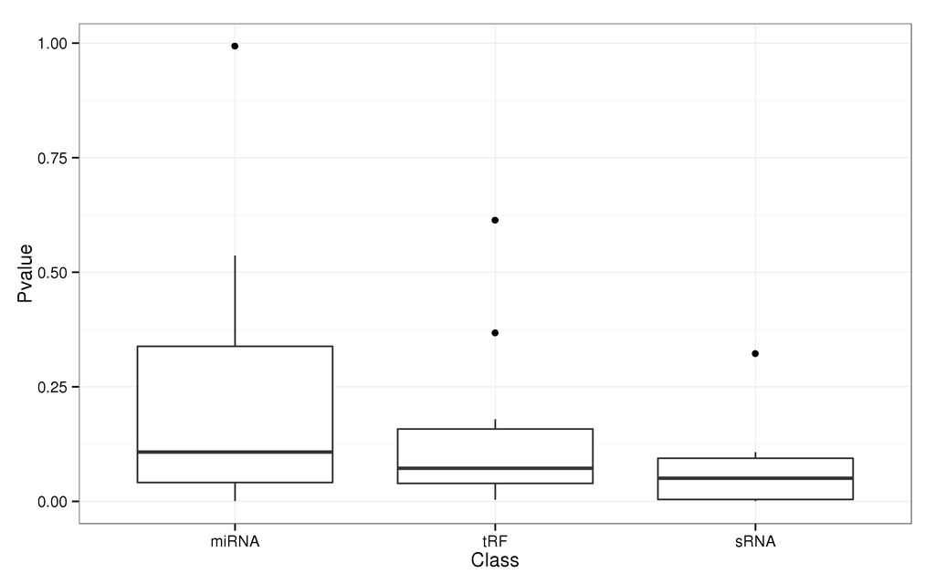

```r
pvals = melt(pvals)
colnames(pvals) = c("Class", "Pvalue")
ggplot(pvals) + geom_boxplot(aes(x = Class, y = Pvalue))
```